# Análisis de variables alternativas de crecimiento mediante un modelo de regresión lineal múltiple

Diego Alonso Garcia (197551)

María Fernanda Claudio González (191725)

Xaymara Anahí Pastrana Ocampo (195393)

# Introducción

El crecimiento económico, entendido como el incremento de la producción de bienes y servicios en una economía de un periodo a otro, es una de las incógnitas más estudiadas por los economistas. No es trivial el interés, cuando una economía crece, sus ciudadanos pueden gozar de más empleo, consumo y en general mayor calidad de vida. Así, procurar el crecimiento económico de un país es una tarea fundamental de cada uno de los gobiernos y demás agentes económicos. Por lo anterior nos preguntamos: ¿cuáles son los motores del crecimiento?

En principio, el crecimiento económico, entendido como el aumento en la producción agregada, se explicaría teóricamente por el cambio de aquellas variables que componen al PIB. En un simple Modelo Keynesiano, estas variables son consumo, inversión, gasto público, importaciones y exportaciones. No obstante, por lo observado en la coyuntura actual del mundo, creemos que existen variables alternas que podrían influenciar el crecimiento económico de un país. Por lo anterior, **el** **objetivo de este proyecto es identificar aquellas variables alternas que influyen en el crecimiento económico de un país**.

Dicho esto, las variables que consideramos en nuestro modelo son crecimiento de la población, tasa de fertilidad en adolescentes, tasa de fertilidad, inflación, esperanza de vida, tasa de mortalidad en niños menores a 5 años, migración neta, suscripciones de teléfono celular y crecimiento de la población urbana. Estudiamos cada una de estas variables de manera gráfica y numérica. Posteriormente, realizamos un modelo de regresión lineal múltiple.

Ahondemos un poco en nuestra base y en la selección de las variables antes de pasar a la definición de nuestro modelo.

## Conjunto de Datos

La base de datos inicial era de panel, pues constenía observaciones que iban desde el año 2000 hasta el 2021 para los diferentes países. Sin embargo, decidimos elaborar el proyecto usando el enfoque del corte transversal y fijar un solo año, el cual se trata del 2021. De este modo, gozamos de 202 observaciones, las cuales corresponden a cada uno de los países. Utilizamos la siguiente fuente para obtener los datos.

1. Baladram,S. (2023). “Global Socio -Economic & Demographic Insights”. *kaggle.* Consultado por última vez el día 29 de noviembre de 2023 de: https://www.kaggle.com/datasets/samybaladram/databank-world-development-indicators/data

## Diccionario de variables

La variable dependiente para la estimación del modelo es el crecimiento del PIB del 2021. Las siguientes variables son aquellas que nos permiten construir la regresión.

1. `GDPGrowth.` es el crecimiento del PIB. Esta es nuestra variable dependiente.
2. `PopGrowth.` es el crecimiento de la población, la cual es la primera regresora.
3. `AdolFertRate` es la tasa de fertilidad adolescente, que es la segunda regresora.
4. `FertRate` es la tasa de fertilidad. Esta es la tercera regresora.
5. `InflConsPric.` es la inflación de los precios del consumidor en porcentaje, la cual es la cuarta regresora.
6. `LifeExpBirth` es la esperanza de vida al nacer. Se trata de la quinta regresora.
7. `MobileSubs.100` son las suscripciones a telefonía por cada 100 personas
8. `MortRateU5` es la tasa de mortalidad de niños menores a cinco años, la cual es séptima regresora.
9. `NetMigr` es la migración neta (diferencia entre número de inmigrantes y emigrantes) que es la octava regresora.
10. `UrbanPopGrowth.` es la tasa de crecimiento de población urbana en porcentaje Esta es la novena regresora

Una explicación más a profundidad de las regresoras (aunque optativa) se encuentra a continuación:

1. El crecimiento de la población es el “incremento en el número de individuos pertenecientes a un determinado ámbito en un año concreto por cada 1000 habitantes” (Instituto Nacional de Estadística de Madrid, 2023). La relación es directa.
2. La tasa de fertilidad de adolescentes (TFA) es aquella que “corresponde al número de nacimientos por cada 1000 mujeres de 15 a 19 años de edad en un año determinado” (Guerrero, 2020). La relación es negativa.
3. La tasa de fertilidad es la “frecuencia con la que un nacimiento vivo completa el proceso reproductivo” (Vinacur et al., 2001, p. 3).
4. La inflación es “es un fenómeno que se observa en la economía de un país y está relacionado con el aumento desordenado de los precios de la mayor parte de los bienes y servicios que se comercian en sus mercados, por un periodo de tiempo prolongado” (BANXICO, 2023).
5. La esperanza de vida al nacer “se refiere a la cantidad de años que viviría un recién nacido si los patrones de mortalidad vigentes al momento de su nacimiento no cambian a lo largo de la vida del infante” (Banco Mundial, 2013).
6. La tasa de mortalidad de niños menores a 5 años es “es la probabilidad de que un niño nacido en un año o período específico muera antes de alcanzar la edad de 5 años” (CEPAL, 2023) y se expresa por cada 1000 niños nacidos vivos.
7. La migración neta son las “inmigraciones menos las emigraciones realizadas en un año concreto por individuos de un determinado ámbito, por cada 1.000 habitantes de ese ámbito” (Instituto Nacional de Estadística de Madrid, 2023).
8. La tasa de suscripciones a telefonía mide el número de suscripciones a servicios telefónicos por cada 100 personas.
9. La tasa de crecimiento de la población urbana, indica la razón a la cual la población urbana incrementa.

Una vez establecidas las variables, podemos comenzar con nuestro Análisis Descriptivo.

# Análisis Descriptivo de los Datos

Lo primero que hacemos es instalar y abrir los paquetes que vamos a ocupar:

```r
# Instalar Librerías
options(repos = "https://cran.r-project.org")
install.packages("ggplot2")
install.packages("DataExplorer")
install.packages("readxl")
install.packages("reshape2")
install.packages("stargazer")
install.packages("car")
install.packages("stats")
install.packages("tseries")
install.packages("corrplot")
install.packages("lmtest")
install.packages("skedastic")
install.packages("sandwich")
install.packages("tinytex")
# Activar Librerías
library(DataExplorer)
library(ggplot2)
library(readxl)
library(reshape2)
library(stargazer)
library(car)
library(stats)
library(tseries)
library(corrplot)
library(lmtest)
library(skedastic)
library(sandwich)
library (tinytex)
```

Luego hacemos la lectura de los datos

```r
archivoCrecimiento<-"C:\\Users\\diego\\Documents\\Econometría\\ProyectoEconometria\\world_development_data_imputed.csv"
datosCrecimiento<-read.csv(archivoCrecimiento)
print(head(datosCrecimiento,n=3))
```

```
##   Year     Country Region       SubRegion SurfAreaSqKm PopTotal    PopDens
## 1 2000 Afghanistan   Asia   Southern Asia       652860 19542982   29.96333
## 2 2000       Malta Europe Southern Europe          320   390087 1219.02187
## 3 2000     Belgium Europe  Western Europe        30530 10251250  338.54855
##   PopGrowth.          GDP GDPGrowth. AdolFertRate AgriValAdd.GDP Exports.GDP
## 1  1.4438030  18012478281  -5.206288      152.572      33.096776    13.31525
## 2  0.6452672   4323339212  19.681791       19.869       1.871997   120.24748
## 3  0.2425180 237000000000   3.716679       11.915       1.176005    72.54740
##   FertRate   FDINetBoP GNI.CapAtlas     GNIAtlas Imports.GDP IndValAdd.GDP
## 1    7.534      170000     916.9233  17786690838    41.31263      17.17877
## 2    1.680   743185325   10950.0000   4273279544   128.37458      26.93999
## 3    1.670 88738714000   25890.0000 265000000000    69.68274      24.94383
##   InflConsPric. LifeExpBirth MerchTrade.GDP MobileSubs.100 MortRateU5  NetMigr
## 1     37.611028     55.29800       52.77705        0.00000      129.3 -1007135
## 2     -4.512396     78.34878      135.68216       28.66747        7.6     1799
## 3      2.014617     77.72195      154.51590       54.84034        5.9    32262
##   UrbanPopGrowth.
## 1       1.8613773
## 2       0.9522992
## 3       0.3084313
```

Y también podemos observar el tipo de variable de cada una de ellas:

```r
tipos_de_variables <- sapply(datosCrecimiento, class)
print(tipos_de_variables)
```

```
##            Year         Country          Region       SubRegion    SurfAreaSqKm
##       "integer"     "character"     "character"     "character"       "numeric"
##        PopTotal         PopDens      PopGrowth.             GDP      GDPGrowth.
##       "integer"       "numeric"       "numeric"       "numeric"       "numeric"
##    AdolFertRate  AgriValAdd.GDP     Exports.GDP        FertRate       FDINetBoP
##       "numeric"       "numeric"       "numeric"       "numeric"       "numeric"
##    GNI.CapAtlas        GNIAtlas     Imports.GDP   IndValAdd.GDP   InflConsPric.
##       "numeric"       "numeric"       "numeric"       "numeric"       "numeric"
##    LifeExpBirth  MerchTrade.GDP  MobileSubs.100      MortRateU5         NetMigr
##       "numeric"       "numeric"       "numeric"       "numeric"       "integer"
## UrbanPopGrowth.
##       "numeric"
```

Preparemos los datos que vamos a ocupar:

```r
datosCrecimiento2021 <- subset(datosCrecimiento, Year == 2021)
datosCrecimiento2021 <- cbind(Index = seq_len(nrow(datosCrecimiento2021)), datosCrecimiento2021)

datosCrecimiento2021 <- datosCrecimiento2021[datosCrecimiento2021$Country != "Cuba", ]

#Exluímos Cuba porque era un super atípico que descomponía todas las pruebas
```

De manera rápida podemos con `DataExplorer()` realizar un reporte de nuestra base de datos.

En el reporte generado podemos ver algunas gráficas útiles como un diagrama de entidad-relación.

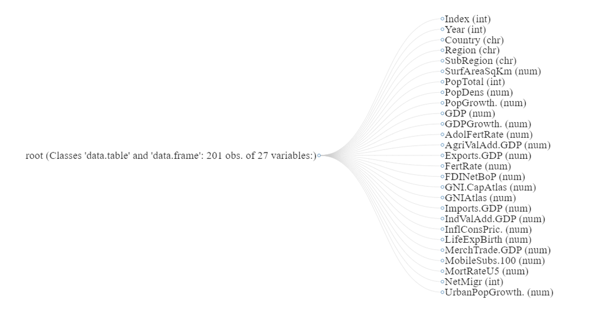

También podemos obtener en el reporte el histograma de las variables. Así podemos esbozar como se distribuyen las variables.

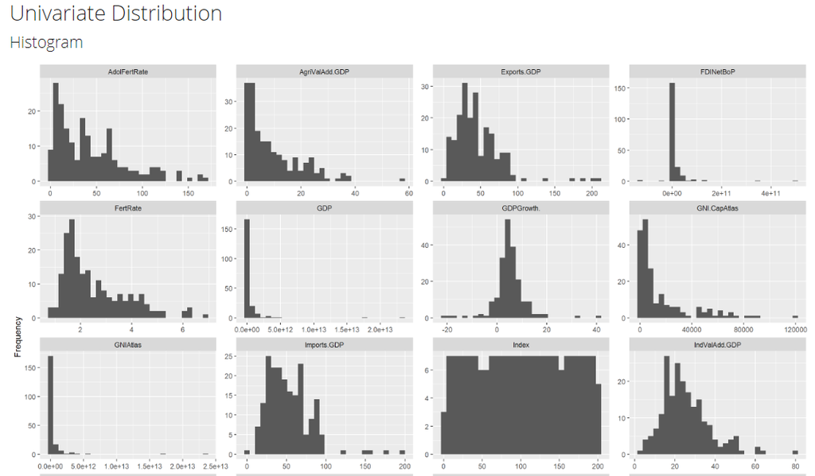

Otra de las gráficas que podemos obtener es un QQ-Plot, el cual nos muestra que si la distribución de las variables se asemeja a una normal entonces los puntos de la gráfica se encontrarán agrupados en la línea de 45°.

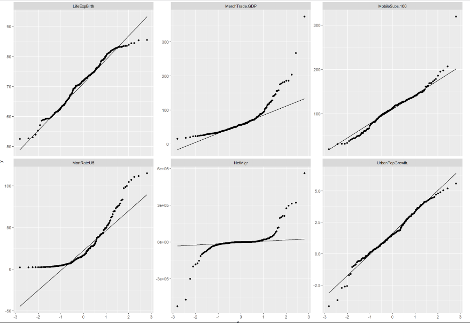

Pero hagamos la interpretación puntual de cada una de las variables:

```r
attach(datosCrecimiento2021)
```

Recordemos las variables del modelo teórico que vamos a ocupar para nuestro modelo:

```r
vars<-data.frame(GDPGrowth.,PopGrowth.,AdolFertRate,FertRate,InflConsPric.,LifeExpBirth,MobileSubs.100,MortRateU5,NetMigr,UrbanPopGrowth.)
print(summary(vars))
```

```
##    GDPGrowth.        PopGrowth.       AdolFertRate        FertRate
##  Min.   :-20.700   Min.   :-4.2566   Min.   :  1.584   Min.   :0.772
##  1st Qu.:  2.562   1st Qu.: 0.2073   1st Qu.: 11.216   1st Qu.:1.595
##  Median :  4.792   Median : 0.9475   Median : 33.929   Median :2.091
##  Mean   :  4.958   Mean   : 0.9264   Mean   : 43.440   Mean   :2.545
##  3rd Qu.:  7.155   3rd Qu.: 1.8885   3rd Qu.: 64.054   3rd Qu.:3.303
##  Max.   : 41.745   Max.   : 3.7074   Max.   :170.462   Max.   :6.820
##  InflConsPric.      LifeExpBirth   MobileSubs.100     MortRateU5
##  Min.   : -4.178   Min.   :52.52   Min.   : 19.45   Min.   :  2.00
##  1st Qu.:  2.216   1st Qu.:65.82   1st Qu.: 88.09   1st Qu.:  6.40
##  Median :  4.685   Median :71.91   Median :112.44   Median : 16.60
##  Mean   : 10.581   Mean   :71.49   Mean   :110.07   Mean   : 26.42
##  3rd Qu.: 10.045   3rd Qu.:76.46   3rd Qu.:131.86   3rd Qu.: 38.60
##  Max.   :235.515   Max.   :85.49   Max.   :319.43   Max.   :115.20
##     NetMigr          UrbanPopGrowth.
##  Min.   :-525116.0   Min.   :-4.1703
##  1st Qu.: -11253.0   1st Qu.: 0.5033
##  Median :   -742.0   Median : 1.5299
##  Mean   :    137.1   Mean   : 1.5840
##  3rd Qu.:   2632.0   3rd Qu.: 2.7889
##  Max.   : 561580.0   Max.   : 5.5835
```

Con `summary()` podemos ver las características generales de cada variable. Específicamente, apreciamos el mínimo, el primer cuartil. la mediana, el promedio, el tercer cuartil y el máximo de cada variable.

Lo primero que analizaremos es la distribución de las variables a través del histograma de cada una

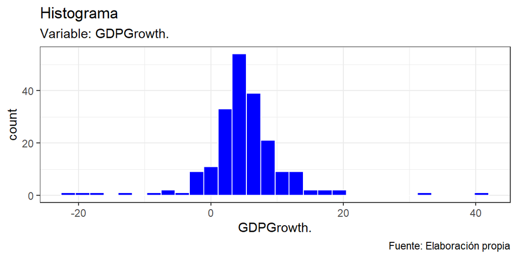

```r
# Histograma
ggplot(data=datosCrecimiento2021,aes(x=GDPGrowth.))+
  geom_histogram(col="white",fill="blue") +
  labs(title="Histograma",
       subtitle = "Variable: GDPGrowth.",
       caption= "Fuente: Elaboración propia")+
  theme_bw()
```

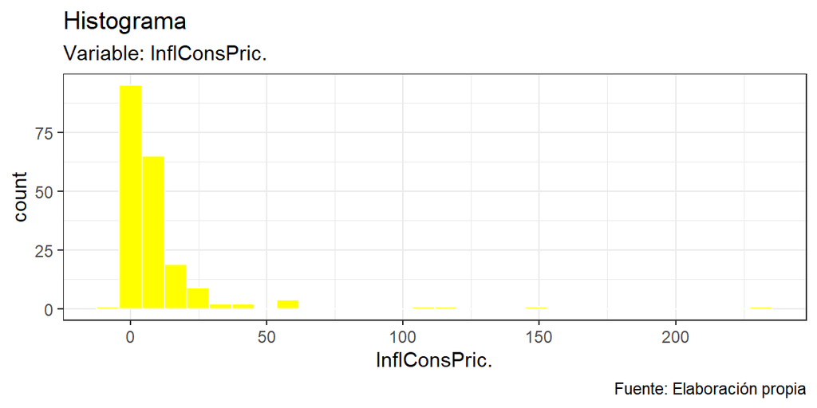

```r
ggplot(data=datosCrecimiento2021,aes(x=InflConsPric.))+
  geom_histogram(col="white",fill="yellow") +
  labs(title="Histograma",
       subtitle = "Variable: InflConsPric.",
       caption= "Fuente: Elaboración propia")+
  theme_bw()
```

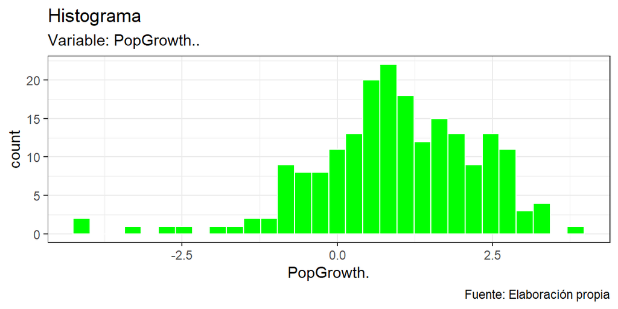

```r
ggplot(data=datosCrecimiento2021,aes(x=PopGrowth.))+
  geom_histogram(col="white",fill="green") +
  labs(title="Histograma",
       subtitle = "Variable: PopGrowth..",
       caption= "Fuente: Elaboración propia")+
  theme_bw()
```

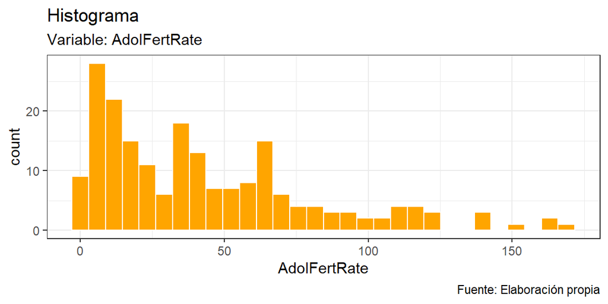

```r
ggplot(data=datosCrecimiento2021,aes(x=AdolFertRate))+
  geom_histogram(col="white",fill="orange") +
  labs(title="Histograma",
       subtitle = "Variable: AdolFertRate",
       caption= "Fuente: Elaboración propia")+
  theme_bw()
```

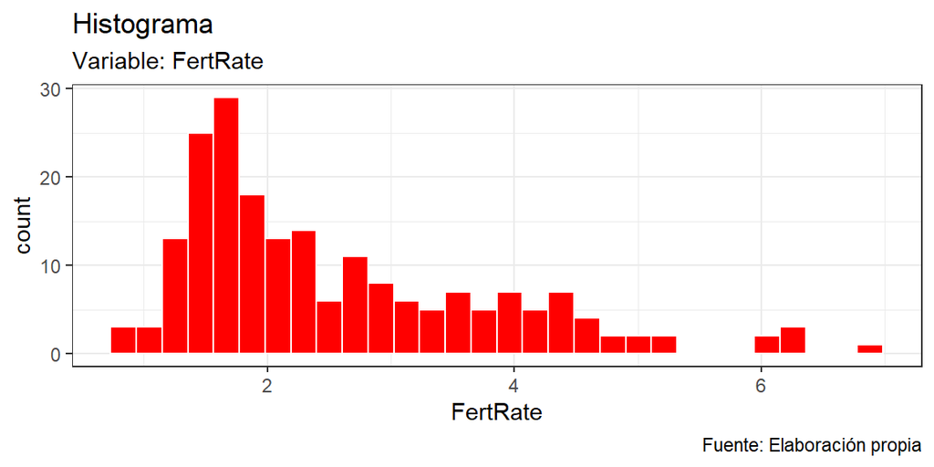

```r
ggplot(data=datosCrecimiento2021,aes(x=FertRate))+
  geom_histogram(col="white",fill="red") +
  labs(title="Histograma",
       subtitle = "Variable: FertRate",
       caption= "Fuente: Elaboración propia")+
  theme_bw()
```

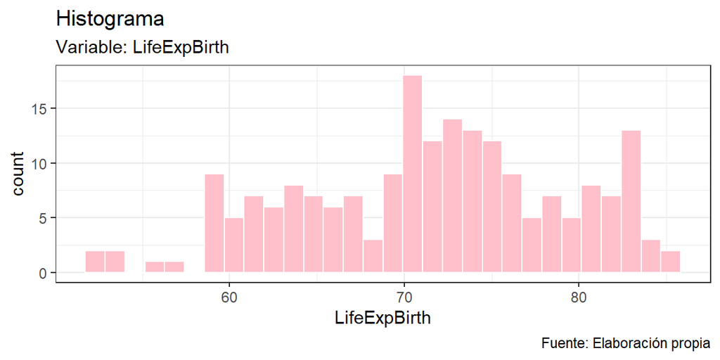

```r
ggplot(data=datosCrecimiento2021,aes(x=LifeExpBirth))+
  geom_histogram(col="white",fill="pink") +
  labs(title="Histograma",
       subtitle = "Variable: LifeExpBirth",
       caption= "Fuente: Elaboración propia")+
  theme_bw()
```

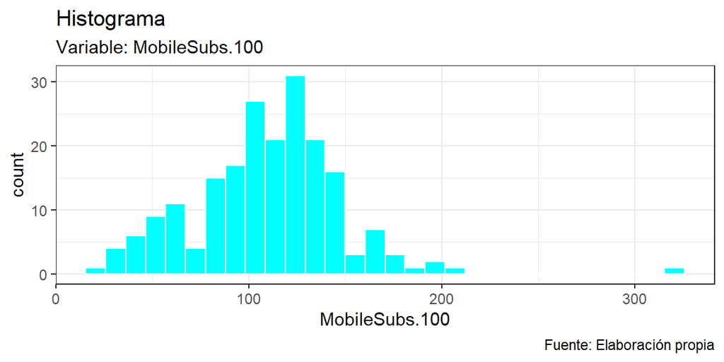

```r
ggplot(data=datosCrecimiento2021,aes(x=MobileSubs.100))+
  geom_histogram(col="white",fill="cyan") +
  labs(title="Histograma",
       subtitle = "Variable: MobileSubs.100",
       caption= "Fuente: Elaboración propia")+
  theme_bw()
```

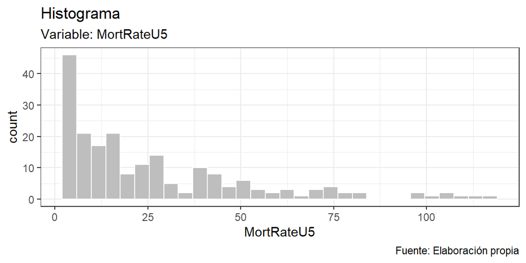

```r
ggplot(data=datosCrecimiento2021,aes(x=MortRateU5))+
  geom_histogram(col="white",fill="grey") +
  labs(title="Histograma",
       subtitle = "Variable: MortRateU5",
       caption= "Fuente: Elaboración propia")+
  theme_bw()
```

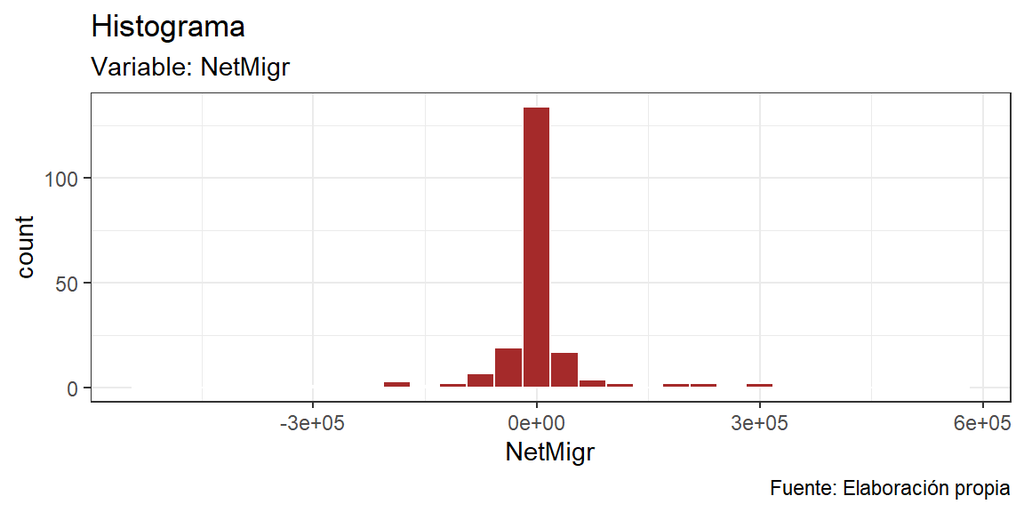

```r
ggplot(data=datosCrecimiento2021,aes(x=NetMigr))+
  geom_histogram(col="white",fill="brown") +
  labs(title="Histograma",
       subtitle = "Variable: NetMigr",
       caption= "Fuente: Elaboración propia")+
  theme_bw()
```

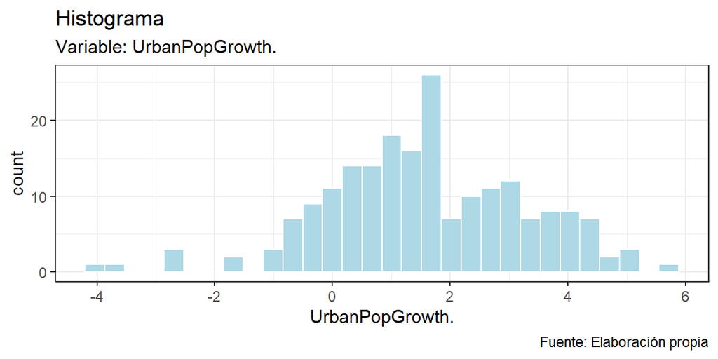

```r
ggplot(data=datosCrecimiento2021,aes(x=UrbanPopGrowth.))+
  geom_histogram(col="white",fill="lightblue") +
  labs(title="Histograma",
       subtitle = "Variable: UrbanPopGrowth.",
       caption= "Fuente: Elaboración propia")+
  theme_bw()
```

El histograma que presenta una distribución más parecida a la normal es la variable explicada. Sin embargo, el crecimiento del PIB presenta más datos atípicos. Los gráficos de la inflación, la tasa de fertilidad adolescente, la tasa de fertilidad y, especialmente, la tasa de mortalidad infantil de menores a cinco años son aquellos que gozan de un sesgo a la derecha.

Por otro lado, el crecimiento poblacional, la esperanza de vida al nacer y el crecimiento de la población urbana presentan un sesgo a la izquierda. No osbtante, estas tres variables tienen el sesgo menos marcado que la inflación. Esta variable y la tasa de mortalidad de niños menores a cinco años son las menos simétricas.

¿Por qué no vemos su dispersión con un diagrama de caja y brazos?

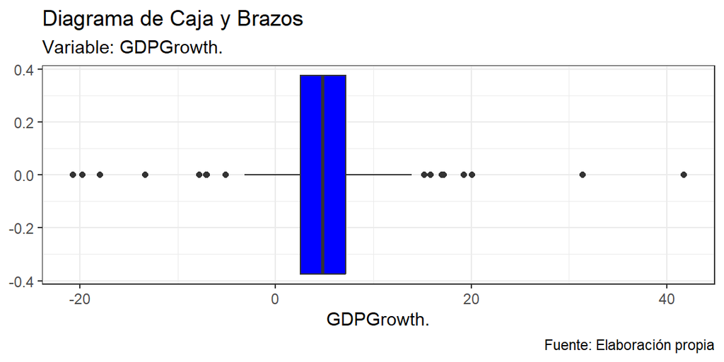

```r
ggplot(data=datosCrecimiento2021,aes(x=GDPGrowth.))+
  geom_boxplot(fill="blue") +
  labs(title="Diagrama de Caja y Brazos",
       subtitle = "Variable: GDPGrowth.",
       caption= "Fuente: Elaboración propia")+
  theme_bw()
```

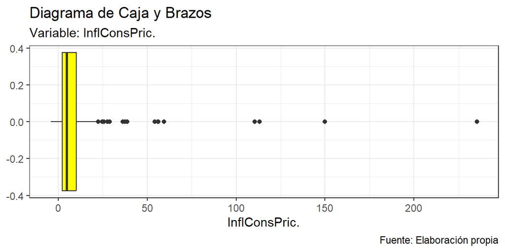

```r
ggplot(data=datosCrecimiento2021,aes(x=InflConsPric.))+
  geom_boxplot(fill="yellow") +
  labs(title="Diagrama de Caja y Brazos",
       subtitle = "Variable: InflConsPric.",
       caption= "Fuente: Elaboración propia")+
  theme_bw()
```

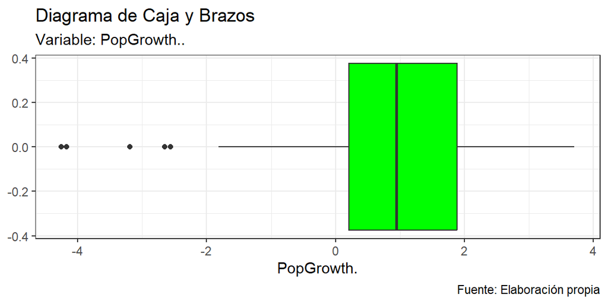

```r
ggplot(data=datosCrecimiento2021,aes(x=PopGrowth.))+
  geom_boxplot(fill="green") +
  labs(title="Diagrama de Caja y Brazos",
       subtitle = "Variable: PopGrowth..",
       caption= "Fuente: Elaboración propia")+
  theme_bw()
```

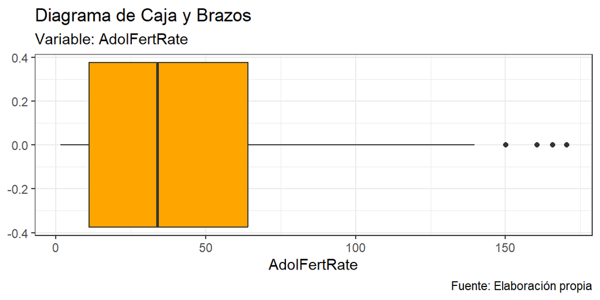

```r
ggplot(data=datosCrecimiento2021,aes(x=AdolFertRate))+
  geom_boxplot(fill="orange") +
  labs(title="Diagrama de Caja y Brazos",
       subtitle = "Variable: AdolFertRate",
       caption= "Fuente: Elaboración propia")+
  theme_bw()
```

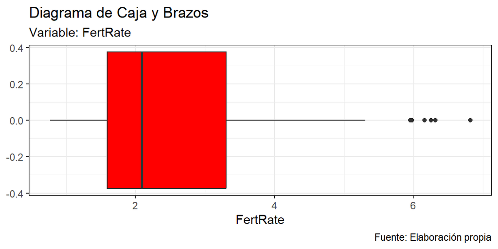

```r
ggplot(data=datosCrecimiento2021,aes(x=FertRate))+
  geom_boxplot(fill="red") +
  labs(title="Diagrama de Caja y Brazos",
       subtitle = "Variable: FertRate",
       caption= "Fuente: Elaboración propia")+
  theme_bw()
```

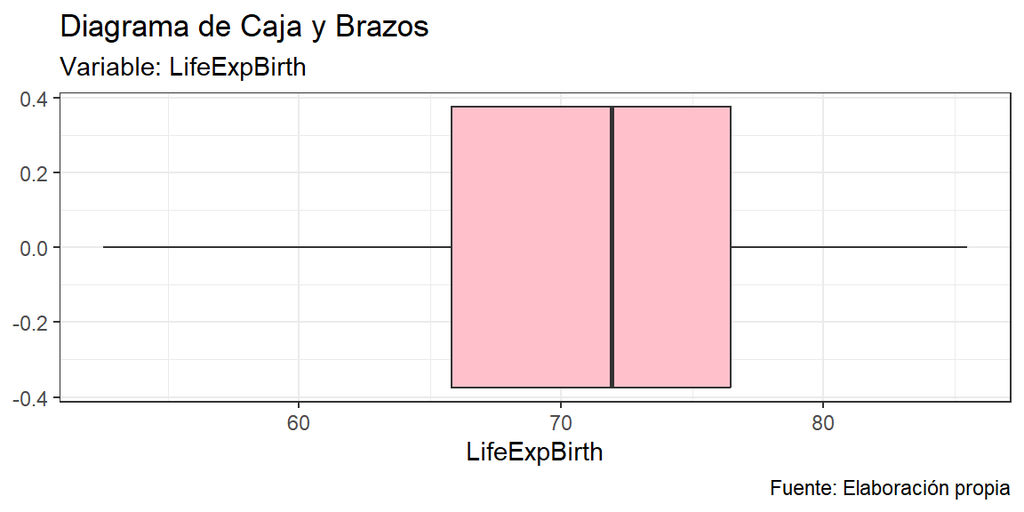

```r
ggplot(data=datosCrecimiento2021,aes(x=LifeExpBirth))+
  geom_boxplot(fill="pink") +
  labs(title="Diagrama de Caja y Brazos",
       subtitle = "Variable: LifeExpBirth",
       caption= "Fuente: Elaboración propia")+
  theme_bw()
```

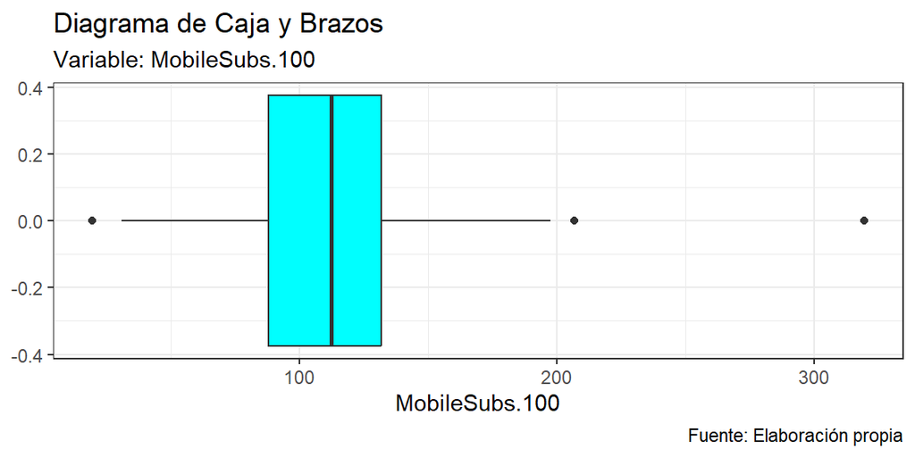

```r
ggplot(data=datosCrecimiento2021,aes(x=MobileSubs.100))+
  geom_boxplot(fill="cyan") +
  labs(title="Diagrama de Caja y Brazos",
       subtitle = "Variable: MobileSubs.100",
       caption= "Fuente: Elaboración propia")+
  theme_bw()
```

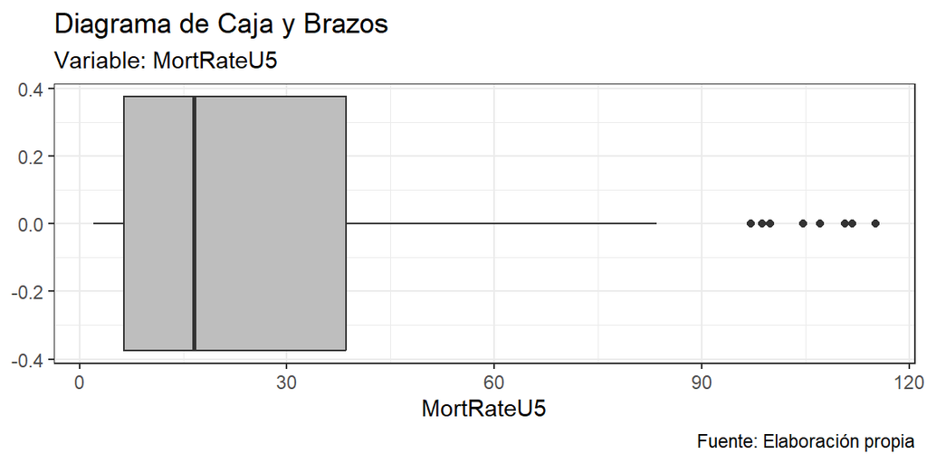

```r
ggplot(data=datosCrecimiento2021,aes(x=MortRateU5))+
  geom_boxplot(fill="grey") +
  labs(title="Diagrama de Caja y Brazos",
       subtitle = "Variable: MortRateU5",
       caption= "Fuente: Elaboración propia")+
  theme_bw()
```

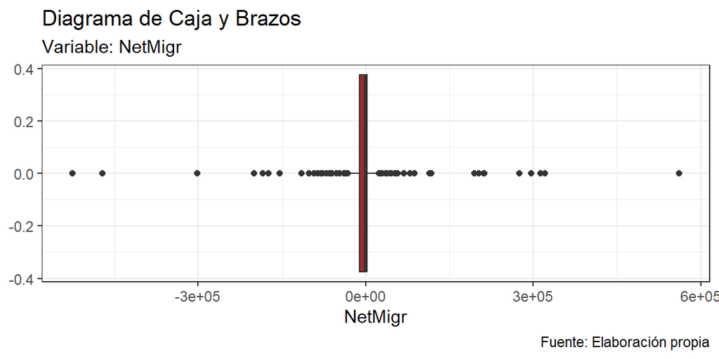

```r
ggplot(data=datosCrecimiento2021,aes(x=NetMigr))+
  geom_boxplot(fill="brown") +
  labs(title="Diagrama de Caja y Brazos",
       subtitle = "Variable: NetMigr",
       caption= "Fuente: Elaboración propia")+
  theme_bw()
```

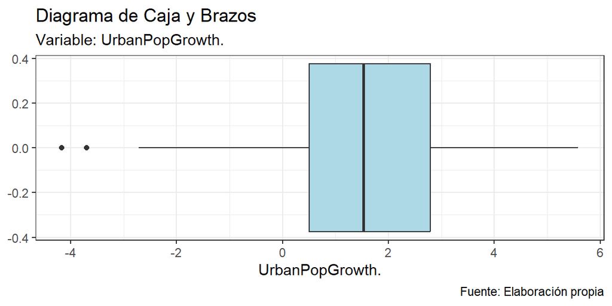

```r
ggplot(data=datosCrecimiento2021,aes(x=UrbanPopGrowth.))+
  geom_boxplot(fill="lightblue") +
  labs(title="Diagrama de Caja y Brazos",
       subtitle = "Variable: UrbanPopGrowth.",
       caption= "Fuente: Elaboración propia")+
  theme_bw()
```

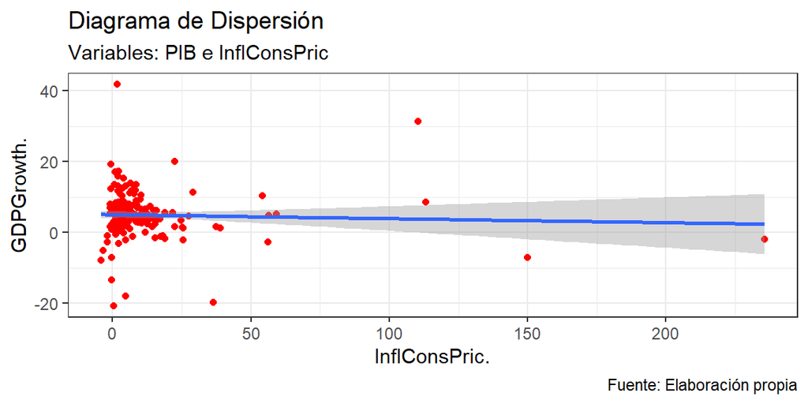

```r
# Diagrama de dispersión
ggplot(data=datosCrecimiento2021,aes(x=InflConsPric.,y=GDPGrowth.))+
  geom_point(col="red",se=TRUE) +
  geom_smooth(method = "lm")+
  labs(title="Diagrama de Dispersión",
       subtitle = "Variables: PIB e InflConsPric",
       caption="Fuente: Elaboración propia")+
  theme_bw()
```

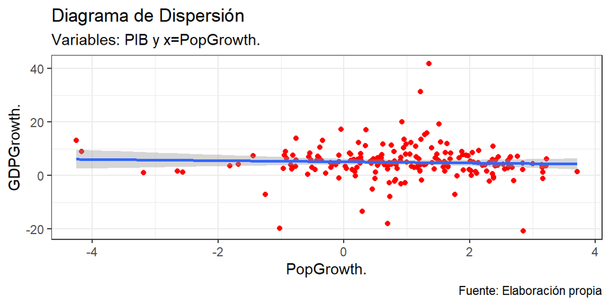

```r
ggplot(data=datosCrecimiento2021,aes(x=PopGrowth.,y=GDPGrowth.))+
  geom_point(col="red") +
  geom_smooth(method = "lm",se=TRUE)+
  labs(title="Diagrama de Dispersión",
       subtitle = "Variables: PIB y x=PopGrowth.",
       caption="Fuente: Elaboración propia")+
  theme_bw()
```

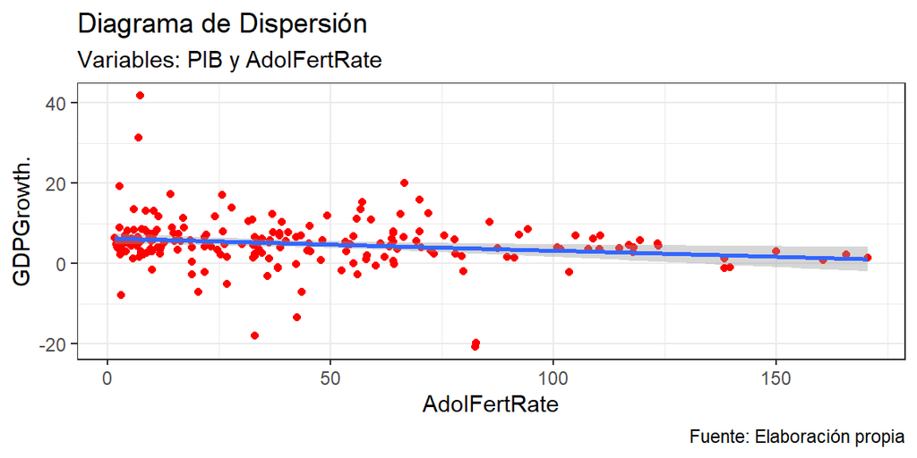

```r
ggplot(data=datosCrecimiento2021,aes(x=AdolFertRate,y=GDPGrowth.))+
  geom_point(col="red") +
  geom_smooth(method = "lm",se=TRUE)+
  labs(title="Diagrama de Dispersión",
       subtitle = "Variables: PIB y AdolFertRate",
       caption="Fuente: Elaboración propia")+
  theme_bw()
```

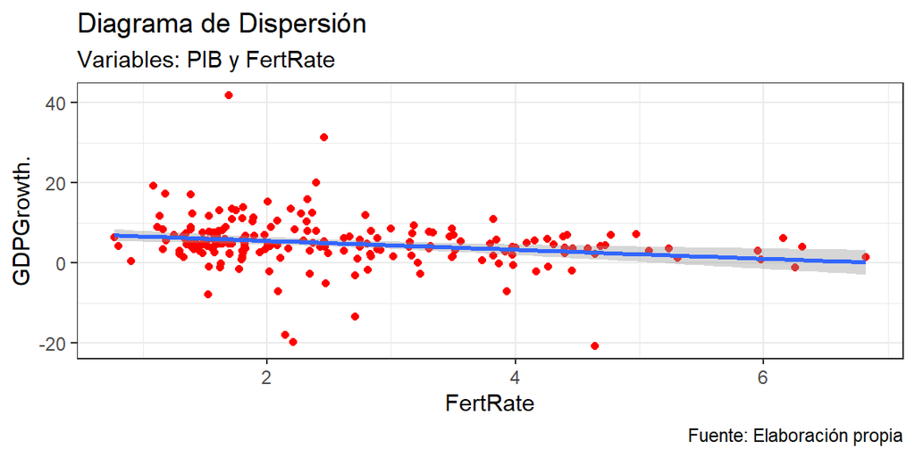

```r
ggplot(data=datosCrecimiento2021,aes(x=FertRate,y=GDPGrowth.))+
  geom_point(col="red") +
  geom_smooth(method = "lm",se=TRUE)+
  labs(title="Diagrama de Dispersión",
       subtitle = "Variables: PIB y FertRate",
       caption="Fuente: Elaboración propia")+
  theme_bw()
```

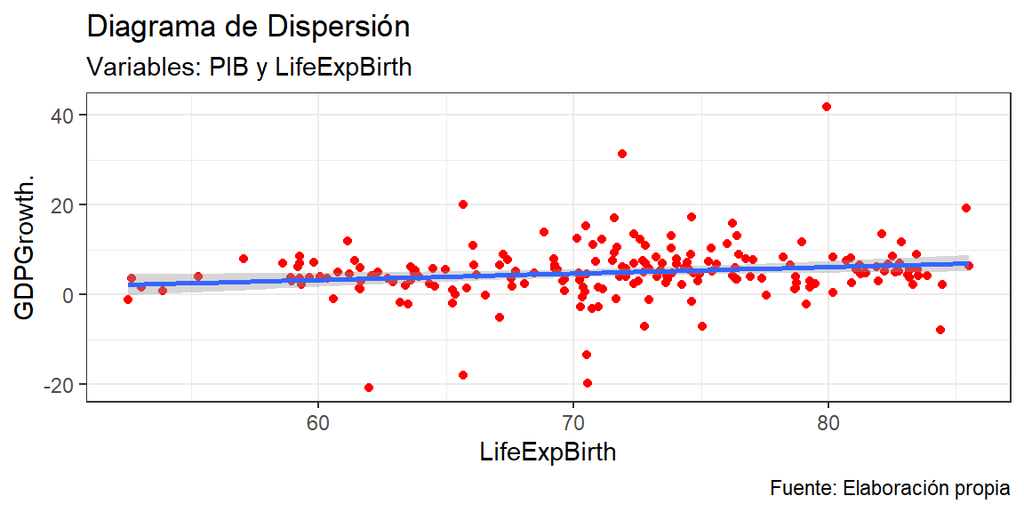

```r
ggplot(data=datosCrecimiento2021,aes(x=LifeExpBirth,y=GDPGrowth.))+
  geom_point(col="red") +
  geom_smooth(method = "lm",se=TRUE)+
  labs(title="Diagrama de Dispersión",
       subtitle = "Variables: PIB y LifeExpBirth",
       caption="Fuente: Elaboración propia")+
  theme_bw()
```

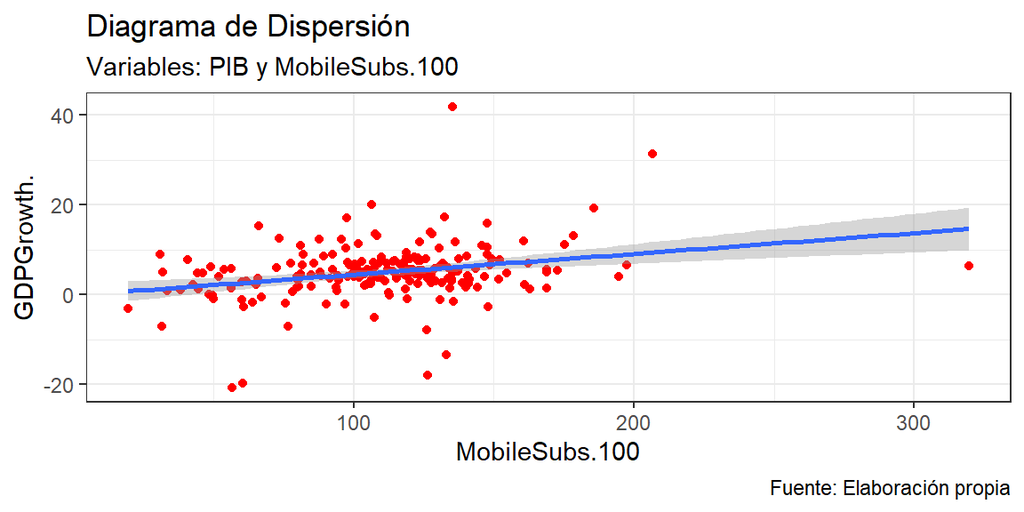

```r
ggplot(data=datosCrecimiento2021,aes(x=MobileSubs.100,y=GDPGrowth.))+
  geom_point(col="red") +
  geom_smooth(method = "lm",se=TRUE)+
  labs(title="Diagrama de Dispersión",
       subtitle = "Variables: PIB y MobileSubs.100",
       caption="Fuente: Elaboración propia")+
  theme_bw()
```

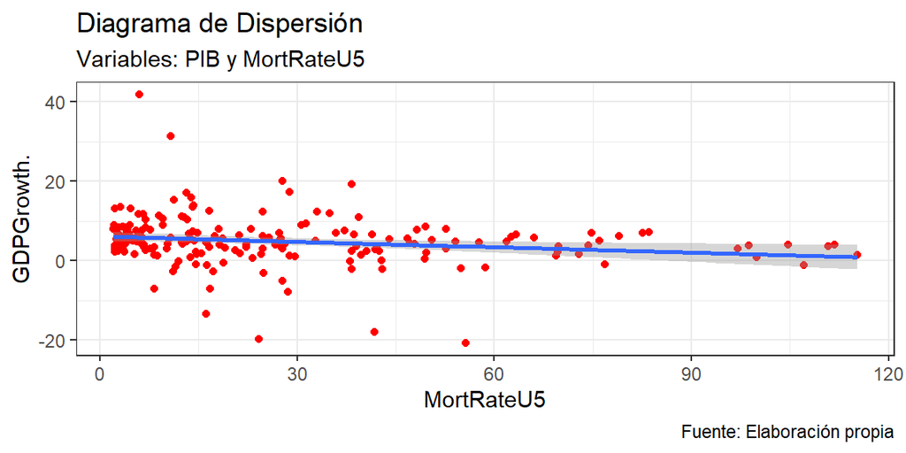

```r
ggplot(data=datosCrecimiento2021,aes(x=MortRateU5,y=GDPGrowth.))+
  geom_point(col="red") +
  geom_smooth(method = "lm",se=TRUE)+
  labs(title="Diagrama de Dispersión",
       subtitle = "Variables: PIB y MortRateU5",
       caption="Fuente: Elaboración propia")+
  theme_bw()
```

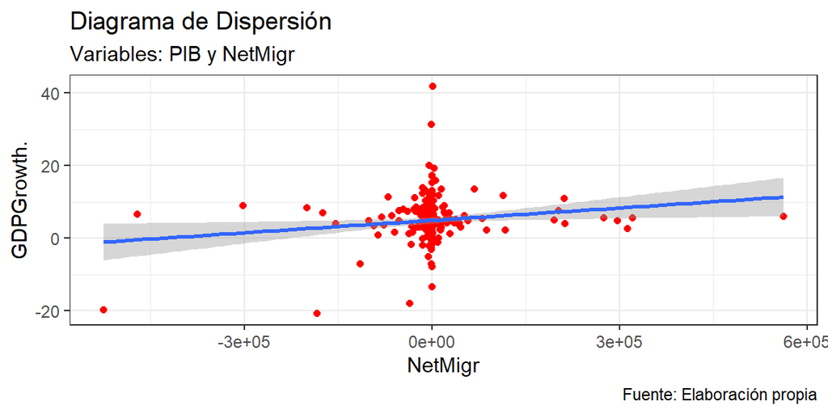

```r
ggplot(data=datosCrecimiento2021,aes(x=NetMigr,y=GDPGrowth.))+
  geom_point(col="red") +
  geom_smooth(method = "lm",se=TRUE)+
  labs(title="Diagrama de Dispersión",
       subtitle = "Variables: PIB y NetMigr",
       caption="Fuente: Elaboración propia")+
  theme_bw()
```

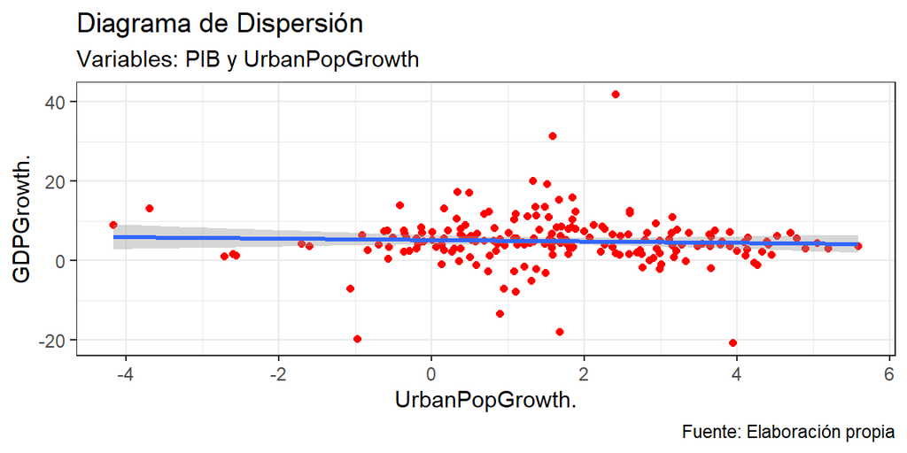

```r
ggplot(data=datosCrecimiento2021,aes(x=UrbanPopGrowth.,y=GDPGrowth.))+
  geom_point(col="red") +
  geom_smooth(method = "lm",se=TRUE)+
  labs(title="Diagrama de Dispersión",
       subtitle = "Variables: PIB y UrbanPopGrowth",
       caption="Fuente: Elaboración propia")+
  theme_bw()
```

A través de los diagramas de dispersión podemos ver la relación que existe entre cada una de las regresoras con la variable dependiente, que en este caso es el crecimiento del PIB. Las variables inflación, crecimiento de la población y crecimiento de la población urbana no muestran tener mucha relación con la variable dependiente. Esto porque la línea de tendencia de estos diagramas no tiene mucha pendiente. Cabe resaltar que en el diagrama de la inflación, aunque hay varios datos atípicos, la mayoría de las observaciones se encuentran entre 0 y 25. Por otro lado, los diagramas de fertilidad entre adolescentes, fertilidad y mortalidad en niños menores a cinco años señalan una relación negativa con el crecimiento económico. Finalmente, la esperanza de vida, las suscripciones de teléfono celular y la migración tienen una relación positiva con el crecimiento del PIB. Una observación interesante es que en el diagrama de migración neta, la mayoría de las observaciones se encuentran alrededor del cero. Una posible explicación de esto es que el flujo de las personas que migran es igual al flujo de personas que inmigran, por lo que el efecto es compensatorio y el número neto de migraciones es cero.